Looking next at histograms of view counts for both the female and the male subsets in the data:

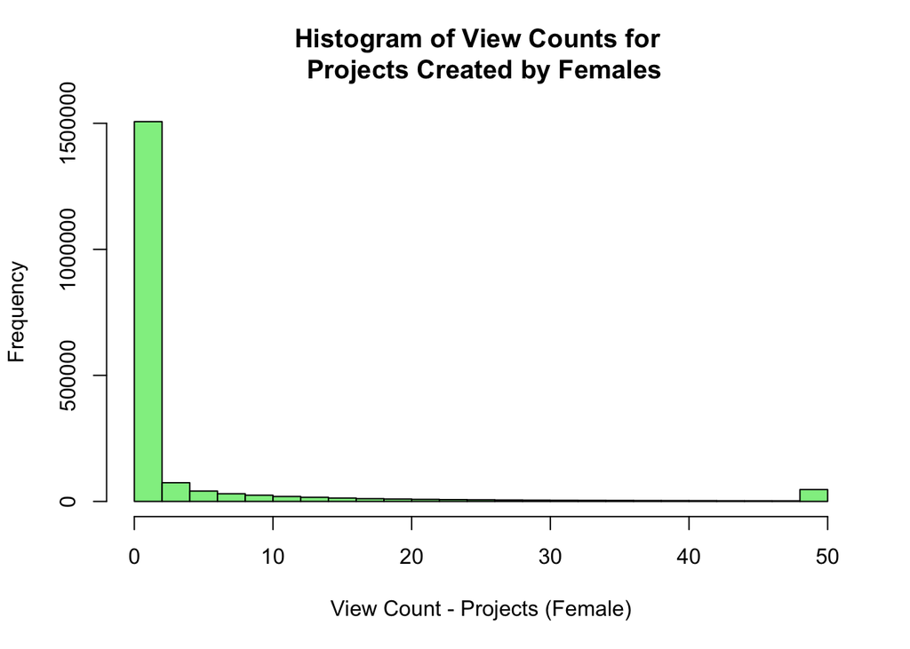

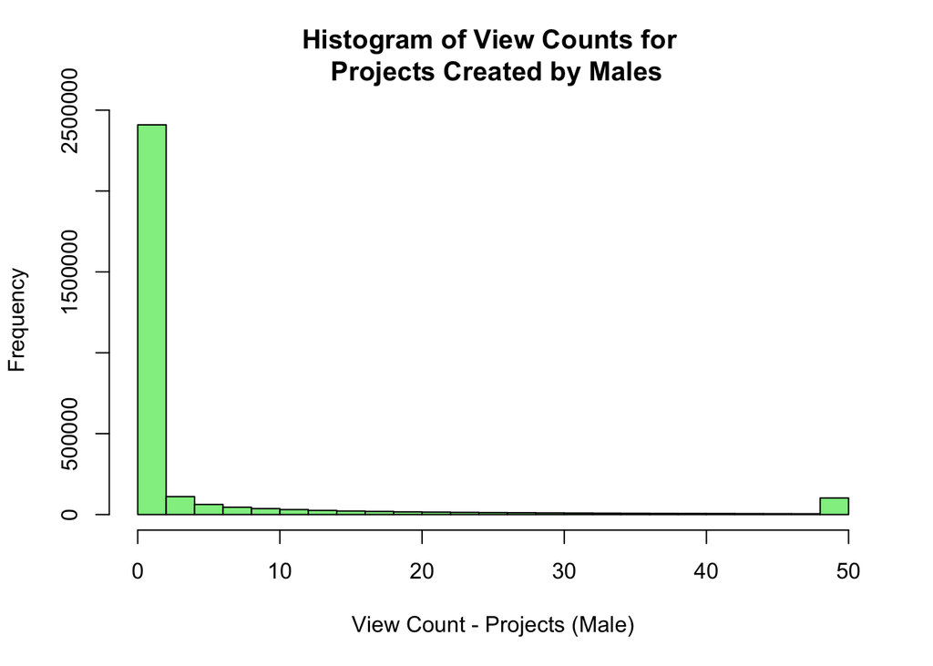

What this shows us is that most projects get very few views. The following plots present the same data, looking at proportions rather than raw counts:

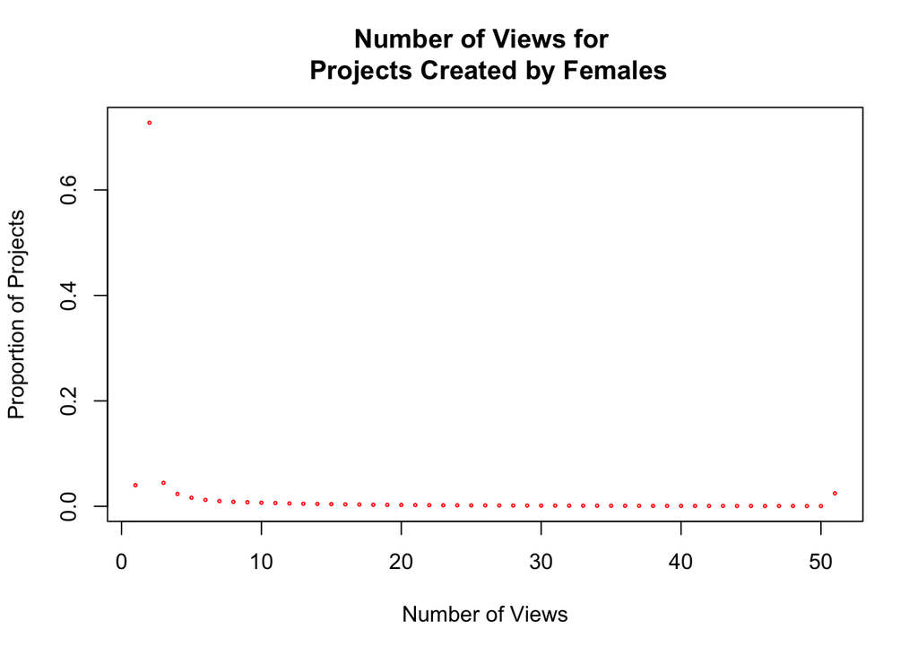

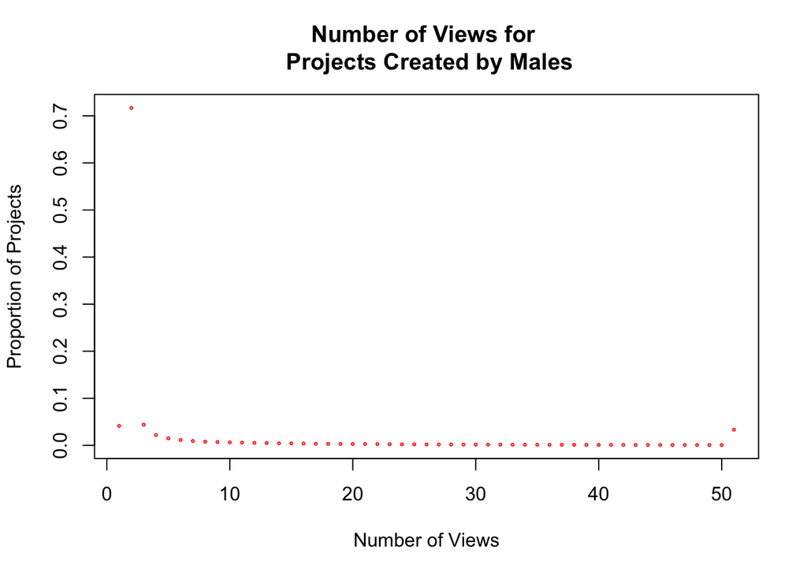

Proportion of Projects Receiving a Given Number of Views

After looking at some features of the entire sample, the data set was processed to add an additional feature, “prev.projects.” This feature makes data on how many projects had been created prior to any given project easy to access, allowing the creation of subsets such as “first.project”, “second.project”, etc.

While number of views is one measure of the interest generated by a project, it is not the only one available to us. A more active measure of positive interest in a given project is the number of love-its the project receives from other Scratchers. The following plots look at the distribution of love-its awarded to projects created by females and males.

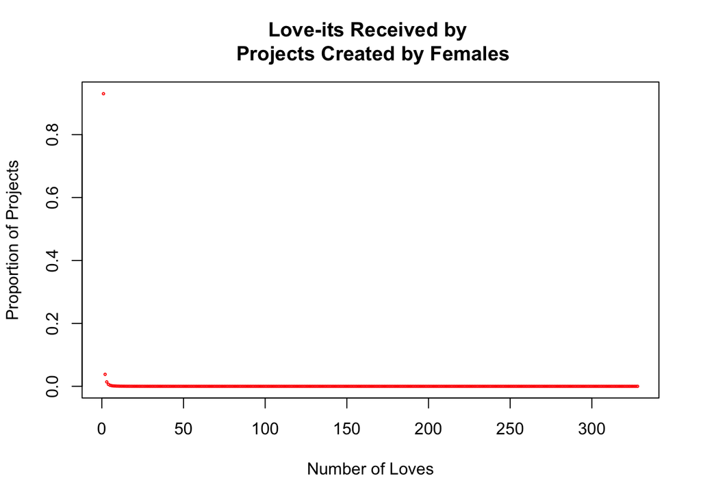

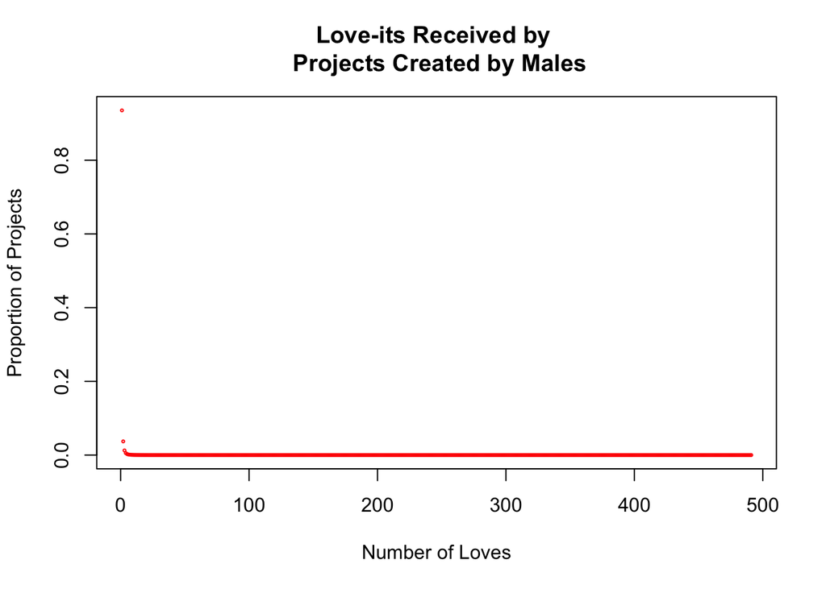

Not surprisingly, most projects receive a small number of love-its. What is notable from these two plots, however, is that the maximum number of love-its received by a single project created by a male is much higher than the maximum received by a project created by female. In addition, the plot shown above is a scatter plot. Thus, it is evident that it is not just a simgle male-created project that got a larger number of love-its than the highest love-it-earning female-created project. In spite of these two observations, the Scratcher with the maximum cumulative total number of love-its received is female (30,119 versus 23,188). For both females and males, the Scratcher with the maximum number of projects is not the same individual as the Scratcher with the largest cumulative love-its total.

We can now look at sharing based on project number and run analyses to look at the effect that reactions to earlier projects has on sharing of later projects.

The following bar plot shows the proportions shared for each of 1st through 5th projects.

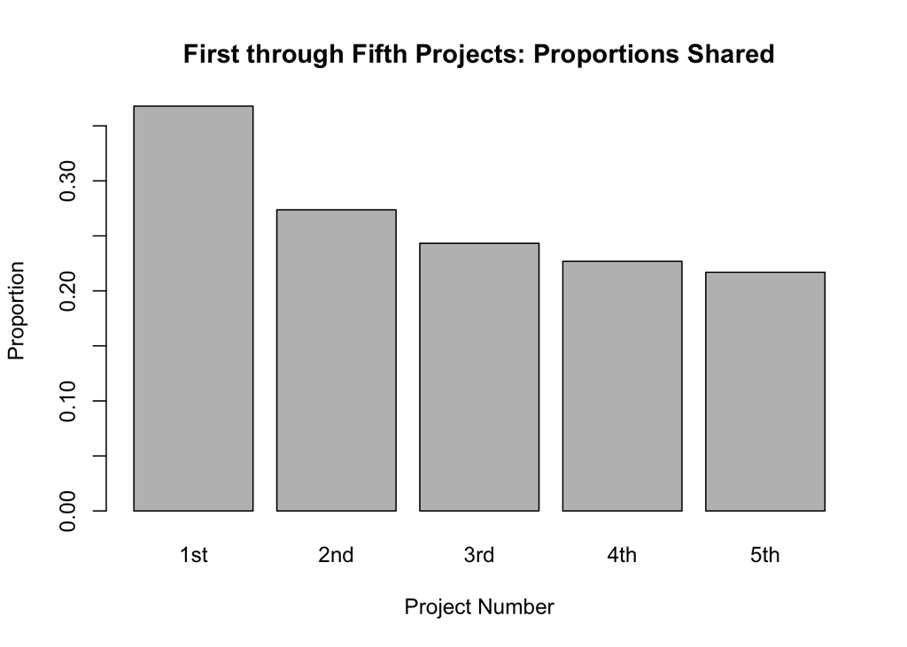

## 6. Data Analysis

### Looking for Gender Differences in Project Sharing

There appears to be a decreasing trend in proportion of projects shared as the number of projects created increases. Next, we’ll look at the data when grouped according to the gender of the project creator. The following bar plot displays the proportions shared by females and males, for easy comparison:

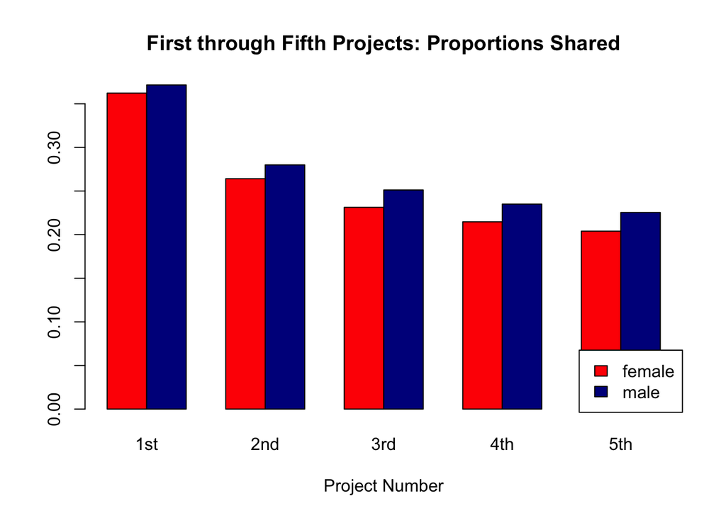

### What Are the Sharing Patterns for Projects?

Performing a test of equal or given proportions (prop.test) will test the null hypothesis that the proportions in each group are the same.

```
##
##  2-sample test for equality of proportions with continuity
##  correction
##
## data:  shared_projects out of all_projects
## X-squared = 220.59, df = 1, p-value < 2.2e-16
## alternative hypothesis: two.sided
## 95 percent confidence interval:
##  0.005275521 0.006883682
## sample estimates:
##    prop 1    prop 2
## 0.2632510 0.2571714
```

*Test of Proportions: Proportion of Shared Projects out of All Projects Created, by Gender*

Loking at the first five projects showed a decreasing trend with females consistently sharing a smaller proportion of their projects than men did. However, the proportions test over the whole dataset was not consistent with this pattern, meaning that at some point, females start sharing more projects relative to males. To get a better sense of what happens over time, we need to look at a longer trend.

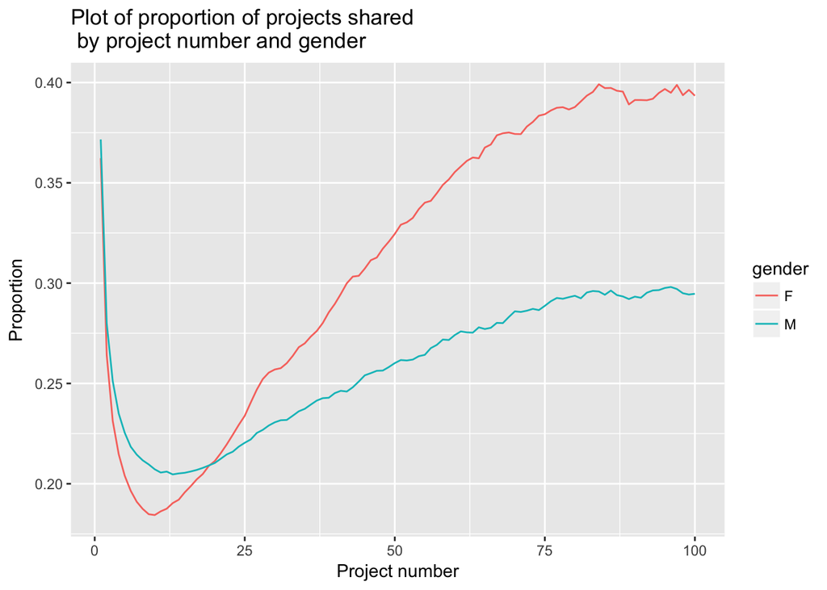

As this plot demonstrates, although females start out less likely to share projects than males, if they go on to create more projects, they begin sharingi them at greater rates, and eventually overtake males for the proportion of projects shared. To see more precisely where the switchover occurs, looking at the data in tabular form is helpful:

[output not shown]

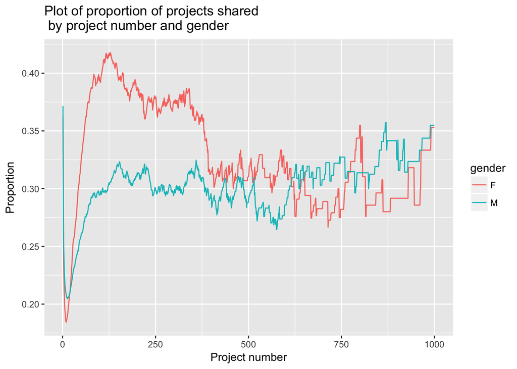

### Effect of First Project Receiving Loveits on Second Project Sharing

When a new Scratcher creates his or her first project, a decision must be made whether ot not to share the project. Once a project is shared, other Scratchers can view the project and react to it. Possible feedback includes the number of views the project attracts, the number of Love-its the project receives, the number of times the project is identified as a “Favorite”, and whether or not the project receives comments. As a first filter for whether a shared project received peer approval, we will look at how Love-its correlate with future project sharing.

Just looking at raw numbers, we see that a relatively low proportion of first projects receiving Love-its. However, when we do a proportions based on project creator’s gender, the difference in female and male projects is significant, with female-created first projects receiving fewer Love-its than male-created first projects:

|  | Female | Male |
| --- | --- | --- |
| Got LoveIts | 12265 | 21295 |
| Got NO LoveIts | 73453 | 112652 |

*Table 3: LoveIts and First Shared Project*

```
##
##  2-sample test for equality of proportions with continuity
##  correction
##
## data:  first_loves out of firsts
## X-squared = 101.91, df = 1, p-value < 2.2e-16
## alternative hypothesis: two.sided
## 95 percent confidence interval:
##  -0.01895930 -0.01283135
## sample estimates:
##    prop 1    prop 2
## 0.1430855 0.1589808
```

*Test of Proportions: Proportion of First Projects Getting LoveIts by Gender*

### Effect of Positive Peer Recognition on Second Project Sharing

We will now use the data on first project sharing to see how receiving Love-its affects whether or not the second project is shared. First, we’ll look at proportions of Scratchers sharing a second project after receiving Love-its for their first project, then at those sharing a second project after the first did NOT receive Love-its:

|  | Female | Male |
| --- | --- | --- |
| 1st Got LoveIts | 7868 | 14058 |
| 1st Got NO LoveIts | 37264 | 58185 |
| Total 2nd Shared Projects | 45132 | 72243 |
| Total 2nd Projects | 170866 | 258014 |

*Table 4: Sharing of Second Projects*

```
##
##  2-sample test for equality of proportions with continuity
##  correction
##
## data:  second_shared_first_loved out of first_proj_got_loves
## X-squared = 11.876, df = 1, p-value = 0.0005687
## alternative hypothesis: two.sided
## 95 percent confidence interval:
##  -0.029325671 -0.007983854
## sample estimates:
##    prop 1    prop 2
## 0.6415002 0.6601550
```

This proportions test is looking at what happens after a first project receives Love-its. We see that among Scratchers who create another project after receiving Love-its for their first project, approximately two-thirds of these second projects will be shared. Again, females are slightly less likely to share their second projects, even after receiving positive feedback for their first projects. This difference is statistically significant.

```
##
##  2-sample test for equality of proportions with continuity
##  correction
##
## data:  second_shared_first_not_loved out of first_proj_got_no_loves
## X-squared = 14.976, df = 1, p-value = 0.0001089
## alternative hypothesis: two.sided
## 95 percent confidence interval:
##  -0.013842026 -0.004527061
## sample estimates:
##    prop 1    prop 2
## 0.5073176 0.5165021
```

If Scratchers go on to create a second project after their first project received no Love-its, fewer of these projects are shared. Only about half of second projects are shared after the first project is shared and fails to receive positive peer feedback. The pattern of females being slightly less likely to share is seen here as well.

Now, we’ll look at second project sharing by Scratchers overall:

```
##
##  2-sample test for equality of proportions with continuity
##  correction
##
## data:  second_projects_shared out of second_projects_all
## X-squared = 129.99, df = 1, p-value < 2.2e-16
## alternative hypothesis: two.sided
## 95 percent confidence interval:
##  -0.01857951 -0.01313974
## sample estimates:
##    prop 1    prop 2
## 0.2641368 0.2799964
```

This proportions test looks at the proportion of shared second projects for all second projects created, differing from the group analyzed above in that it includes second projects created by Scratchers who chose not to share their first projects, as well as those who shared their first projects. Similar to the pattern seen for first project sharing, relatively few created projects are actually shared.

Now we will look at the proportion of shared second projects whose creators got Love-its for their first project – i.e. out of all second projects that are shared, how many are shared by people who received Loveits on their first projects?

```
##
##  2-sample test for equality of proportions with continuity
##  correction
##
## data:  first_loved out of second_projects_shared
## X-squared = 63.432, df = 1, p-value = 1.66e-15
## alternative hypothesis: two.sided
## 95 percent confidence interval:
##  -0.02595798 -0.01573734
## sample estimates:
##    prop 1    prop 2
## 0.2422228 0.2630705
```

Finally, this proportions test looks at the proportion of shared second projects whose creators did not receive Love-its for their first project – i.e. out of all second projects that are shared, how many were created by prople who did not get Love-its for their first projects?

```
##
##  2-sample test for equality of proportions with continuity
##  correction
##
## data:  second_projects_shared out of not.first_loved
## X-squared = 185.75, df = 1, p-value < 2.2e-16
## alternative hypothesis: two.sided
## 95 percent confidence interval:
##  -0.02294754 -0.01719082
## sample estimates:
##    prop 1    prop 2
## 0.2821914 0.3022606
```

## 7. Hypothesis Testing

To restate the null hypotheses being investigated:

1. Projects created by females are just as likely to be shared as projects created by males.
2. Projects created by females are just as likely to receive peer recognition as projects created by males.
3. Scratchers whose shared projects receive no peer recognition are just as likely to share future projects as are Scratchers whose earlier shared projects did receive peer recognition.
4. Female Scratchers whose shared projects receive no peer recognition are just as likely to share future projects as are male Scratchers whose shared projects receive no peer recognition.

### Hypothesis 1

- Projects created by females are just as likely to be shared as projects created by males.
- logit(p(share) given gender, previous projects))

```
##
## Call:
## glm(formula = shared ~ female + log1p(prev.projects) + female *
##     log1p(prev.projects), family = binomial("logit"), data = info_data)
##
## Deviance Residuals:
##     Min       1Q   Median       3Q      Max
## -0.8691  -0.7844  -0.7637   1.5763   1.7534
##
## Coefficients:
##                                   Estimate Std. Error z value Pr(>|z|)
## (Intercept)                     -0.9572917  0.0023239 -411.94   <2e-16 ***
## femaleTRUE                      -0.1799691  0.0037296  -48.26   <2e-16 ***
## log1p(prev.projects)            -0.0444043  0.0008308  -53.45   <2e-16 ***
## femaleTRUE:log1p(prev.projects)  0.0911158  0.0013166   69.21   <2e-16 ***
## ---
## Signif. codes:  0 '***' 0.001 '**' 0.01 '*' 0.05 '.' 0.1 ' ' 1
##
## (Dispersion parameter for binomial family taken to be 1)
##
##     Null deviance: 5564039  on 4859201  degrees of freedom
## Residual deviance: 5558860  on 4859198  degrees of freedom
## AIC: 5558868
##
## Number of Fisher Scoring iterations: 4
```

- Projects created by females are just as likely to receive peer recognition as projects created by males.
- logit(p(love>0) given gender, previous proojects))

```
##
## Call:
## glm(formula = got.love ~ female + log1p(prev.projects), family = binomial("logit"),
##     data = info_data)
##
## Deviance Residuals:
##     Min       1Q   Median       3Q      Max
## -3.3309  -0.6872  -0.3193   0.5886   2.4502
##
## Coefficients:
##                       Estimate Std. Error  z value Pr(>|z|)
## (Intercept)          -3.574475   0.003314 -1078.70   <2e-16 ***
## femaleTRUE           -0.189948   0.002541   -74.75   <2e-16 ***
## log1p(prev.projects)  1.174018   0.001100  1067.66   <2e-16 ***
## ---
## Signif. codes:  0 '***' 0.001 '**' 0.01 '*' 0.05 '.' 0.1 ' ' 1
##
## (Dispersion parameter for binomial family taken to be 1)
##
##     Null deviance: 6284980  on 4859201  degrees of freedom
## Residual deviance: 4158858  on 4859199  degrees of freedom
## AIC: 4158864
##
## Number of Fisher Scoring iterations: 5
```

### Hypothesis 3

For this test, the log of the total of previously received Love-its was used.

- Scratchers whose shared projects receive no peer recognition are just as likely to share future projects as are Scratchers whose earlier shared projects did receive peer recognition.
- logit(p(share) given recognition, previous projects)

```
##
## Call:
## glm(formula = shared ~ log1p(prev.projects) + log1p(previous.total.love),
##     family = binomial("logit"), data = info_data)
##
## Deviance Residuals:
##     Min       1Q   Median       3Q      Max
## -3.0156  -0.7833  -0.5783   0.9086   2.8213
##
## Coefficients:
##                             Estimate Std. Error z value Pr(>|z|)
## (Intercept)                -0.508627   0.001920  -265.0   <2e-16 ***
## log1p(prev.projects)       -0.574802   0.001109  -518.5   <2e-16 ***
## log1p(previous.total.love)  0.695544   0.001051   661.7   <2e-16 ***
## ---
## Signif. codes:  0 '***' 0.001 '**' 0.01 '*' 0.05 '.' 0.1 ' ' 1
##
## (Dispersion parameter for binomial family taken to be 1)
##
##     Null deviance: 5564039  on 4859201  degrees of freedom
## Residual deviance: 5027014  on 4859199  degrees of freedom
## AIC: 5027020
##
## Number of Fisher Scoring iterations: 4
```

### Hypothesis 4

For this test, the log of the total of previously received Love-its was used. The interaction of female with a binary received Love-its or not term was also included.

- Female Scratchers whose shared projects receive no peer recognition are just as likely to share future projects as are male Scratchers whose shared projects receive no peer recognition.
- logit(p(share) given recognition, gender, previous projects)

```
##
## Call:
## glm(formula = shared ~ female + log1p(prev.projects) + log1p(previous.total.love) +
##     female * got.love, family = binomial("logit"), data = info_data)
##
## Deviance Residuals:
##     Min       1Q   Median       3Q      Max
## -2.6309  -0.7653  -0.5273   0.9024   3.0342
##
## Coefficients:
##                             Estimate Std. Error  z value Pr(>|z|)
## (Intercept)                -0.621687   0.002336 -266.108  < 2e-16 ***
## femaleTRUE                 -0.017266   0.003093   -5.582 2.37e-08 ***
## log1p(prev.projects)       -0.658311   0.001169 -563.073  < 2e-16 ***
## log1p(previous.total.love)  0.485222   0.001171  414.428  < 2e-16 ***
## got.love                    1.232864   0.003885  317.350  < 2e-16 ***
## femaleTRUE:got.love         0.182094   0.004616   39.451  < 2e-16 ***
## ---
## Signif. codes:  0 '***' 0.001 '**' 0.01 '*' 0.05 '.' 0.1 ' ' 1
##
## (Dispersion parameter for binomial family taken to be 1)
##
##     Null deviance: 5564039  on 4859201  degrees of freedom
## Residual deviance: 4892296  on 4859196  degrees of freedom
## AIC: 4892308
##
## Number of Fisher Scoring iterations: 4
```